# Worst Drivers

Trying out crosstalk and other packages with data from blog post about examinging 538 data. See https://www.mytinyshinys.com/post/badDrivers_538/

Load libraries (note, we need the github version of plotly… `devtools::install_github("ropensci/plotly")` )

```r
library(htmltools)
library(plotly)
library(fivethirtyeight)
library(crosstalk)
library(tabulizer)
library(DT)
library(dplyr)
library(tidyr)
library(stringr)
```

I got a file with state information at http://www.fonz.net/blog/wp-content/uploads/2008/04/states.csv . Make it nicer.

```r
states <- read.csv("states.csv") %>% rename(state=State, stateID=Abbreviation) %>%
                                 mutate_each( funs(as.character), everything())
glimpse(states)
```

```
Observations: 51
Variables: 2
$ state   <chr> "Alabama", "Alaska", "Arizona", "Arkansas", "California", "Colorado", "Connect...
$ stateID <chr> "AL", "AK", "AZ", "AR", "CA", "CO", "CT", "DE", "DC", "FL", "GA", "HI", "ID", ...
```

Here is the plot to improve…

[figure not shown]

Image to improve

Let’s get the data. The `fivethirtyeight` package has a data set called `bad_drivers`. Column definitions are at https://github.com/fivethirtyeight/data/tree/master/bad-drivers .

```r
df <- bad_drivers
glimpse(df)
```

```
Observations: 51
Variables: 8
$ state               <chr> "Alabama", "Alaska", "Arizona", "Arkansas", "California", "Colorad...
$ num_drivers         <dbl> 18.8, 18.1, 18.6, 22.4, 12.0, 13.6, 10.8, 16.2, 5.9, 17.9, 15.6, 1...
$ perc_speeding       <int> 39, 41, 35, 18, 35, 37, 46, 38, 34, 21, 19, 54, 36, 36, 25, 17, 27...
$ perc_alcohol        <int> 30, 25, 28, 26, 28, 28, 36, 30, 27, 29, 25, 41, 29, 34, 29, 25, 24...
$ perc_not_distracted <int> 96, 90, 84, 94, 91, 79, 87, 87, 100, 92, 95, 82, 85, 94, 95, 97, 7...
$ perc_no_previous    <int> 80, 94, 96, 95, 89, 95, 82, 99, 100, 94, 93, 87, 98, 96, 95, 87, 8...
$ insurance_premiums  <dbl> 784.55, 1053.48, 899.47, 827.34, 878.41, 835.50, 1068.73, 1137.87,...
$ losses              <dbl> 145.08, 133.93, 110.35, 142.39, 165.63, 139.91, 167.02, 151.48, 13...
```

Let’s work on the data. First, remove the insurance and losses columns. Then use `tidyr` to switch from the wide data to a narrow data. To do that, we’ll `gather` the `perc_...` columns with title of `cause` and value of `pc` (percent). What we want is number of drivers involved in such accidents per billion miles. The `num_drivers` column is that total number of fatalities per billion miles. So we can convert from percent to absolute number. Finally, we want the abbreviation instead of the state name.

```r
df %>%
  select(1:6) %>%                                       # drop insurance_premiums and losses
  gather(cause, pc, -c(state, num_drivers)) %>%         # Make narrow DF
  mutate(value = round(num_drivers * pc / 100, 1)) %>%  # Absolute values
  left_join(states) -> df_gather
glimpse(df_gather)
```

```
Observations: 204
Variables: 6
$ state       <chr> "Alabama", "Alaska", "Arizona", "Arkansas", "California", "Colorado", "Con...
$ num_drivers <dbl> 18.8, 18.1, 18.6, 22.4, 12.0, 13.6, 10.8, 16.2, 5.9, 17.9, 15.6, 17.5, 15....
$ cause       <chr> "perc_speeding", "perc_speeding", "perc_speeding", "perc_speeding", "perc_...
$ pc          <int> 39, 41, 35, 18, 35, 37, 46, 38, 34, 21, 19, 54, 36, 36, 25, 17, 27, 19, 35...
$ value       <dbl> 7.3, 7.4, 6.5, 4.0, 4.2, 5.0, 5.0, 6.2, 2.0, 3.8, 3.0, 9.4, 5.5, 4.6, 3.6,...
$ stateID     <chr> "AL", "AK", "AZ", "AR", "CA", "CO", "CT", "DE", "DC", "FL", "GA", "HI", "I...
```

Let’s turn the states into a factor

```r
df_gather %>% mutate(state = factor(state, levels=state[order(value)])) -> df_gather
```

```
duplicated levels in factors are deprecated
```

```r
df_gather
```

| state | num_drivers | cause | pc | value | stateID |
| --- | --- | --- | --- | --- | --- |
| Alabama | 18.8 | perc_speeding | 39 | 7.3 | AL |
| Alaska | 18.1 | perc_speeding | 41 | 7.4 | AK |
| Arizona | 18.6 | perc_speeding | 35 | 6.5 | AZ |
| Arkansas | 22.4 | perc_speeding | 18 | 4.0 | AR |
| California | 12.0 | perc_speeding | 35 | 4.2 | CA |
| Colorado | 13.6 | perc_speeding | 37 | 5.0 | CO |
| Connecticut | 10.8 | perc_speeding | 46 | 5.0 | CT |
| Delaware | 16.2 | perc_speeding | 38 | 6.2 | DE |
| District of Columbia | 5.9 | perc_speeding | 34 | 2.0 | DC |
| Florida | 17.9 | perc_speeding | 21 | 3.8 | FL |

[output cut: 194 more lines]

Set up things for `crosstalk`

```r
sd <- SharedData$new(df_gather)  # crosstalk  - data to pass to widgets
fs <- filter_select(   # Create a select box (crosstalk)
  id = "cause",
  label = 'Cause',
  sharedData = sd,
  group = ~ cause,
  allLevels = FALSE,
  multiple = FALSE
  )
```

Apparenlty there’s extra work to use bootstrap (not sure what that is). There are many `html_dependencies` attributes and we are keeping all of them except for the one named `bootstrap`.

```r
fs_nobootstrap <- fs
attr(fs_nobootstrap, "html_dependencies") <- Filter(
  function(dep) {dep$name != "bootstrap"}, attr(fs_nobootstrap, "html_dependencies")
)
```

Make the chart (this doesn’t quite look like the blog - that code didn’t work).

```r
myChart <- sd %>%
  plot_ly(
           x = ~ num_drivers,
           y = ~ state,
           height = 800) %>%
  add_bars(width=0.8, color = I("#f2dfa8"), name="Total") %>%   # All fatalities
  add_bars(width=0.2, x = ~ value, y = ~ state, color = I("#F6B900"),  # according to cause
           name = "Cause", hoverinfo = "text", text = ~paste0(pc, "%")) %>%
  layout(barmode="overlay",
         title="Drivers involved in Fatal collisions by State - 2012",
         xaxis=list(title="Fatal collisions per billion miles"),
         yaxis=list(title=""),
         margin=list(l=120)) %>%
  config(displayModeBar=F, showLink=F)
# Conbine chart and selector
tagList(fs_nobootstrap, myChart)
```

Cause

[interactive chart not shown]

It works!!!

Let’s try some maps!

```r
sd %>%
  plot_ly(type="choropleth",
          locations = ~ stateID,
          locationmode = "USA-states",
          z = ~ value,
          reversescale = TRUE) %>%
  layout(geo = list(scope="usa")) -> map
tagList(fs_nobootstrap, map)
```

Cause

[interactive chart not shown]

There seems to be a bug on the web page … if you select a category from one plot, selecting a category from another plot no longer works. Anyway,…

The blog post goes on to talk about where the data actually comes from. There’s a PDF table with some interesting accident data. Here’s a copy that I cut and pasted…

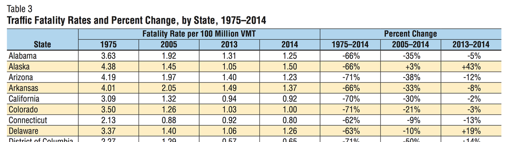

PDF table

We can use the `tabulizer` package to look at it. For some reason, `tabulizer::extract_tables` and regular `download.file` got a 405 error (Method not allowed). Doing `download.file` with `method=wget` works. Note that for `extract_table`, we don’t specify `mode=data.frame` as that turns the first row into column headers. The approach here seems better.

```r
download.file("https://crashstats.nhtsa.dot.gov/Api/Public/ViewPublication/812293",
              destfile = 'worstDrivers_aux/table3.pdf', method="wget")
crash_data <- extract_tables("worstDrivers_aux/table3.pdf", pages=5 )
```

```
There is already a file with this name in the temporary directory. It will be overwritten.
```

```r
df <- as.data.frame(crash_data)
df
```

| X1 | X2 | X3 | X4 | X5 | X6 | X7 | X8 |
| --- | --- | --- | --- | --- | --- | --- | --- |
| Alabama | 3.63 | 1.92 | 1.31 | 1.25 | -66% | -35% | -5% |
| Alaska | 4.38 | 1.45 | 1.05 | 1.50 | -66% | +3% | +43% |
| Arizona | 4.19 | 1.97 | 1.40 | 1.23 | -71% | -38% | -12% |
| Arkansas | 4.01 | 2.05 | 1.49 | 1.37 | -66% | -33% | -8% |
| California | 3.09 | 1.32 | 0.94 | 0.92 | -70% | -30% | -2% |
| Colorado | 3.50 | 1.26 | 1.03 | 1.00 | -71% | -21% | -3% |
| Connecticut | 2.13 | 0.88 | 0.92 | 0.80 | -62% | -9% | -13% |
| Delaware | 3.37 | 1.40 | 1.06 | 1.26 | -63% | -10% | +19% |
| District of Columbia | 2.27 | 1.29 | 0.57 | 0.65 | -71% | -50% | +14% |
| Florida | 3.24 | 1.75 | 1.25 | 1.24 | -62% | -29% | -1% |

[output cut: 43 more lines]

```r
glimpse(df)
```

```
Observations: 53
Variables: 8
$ X1 <fctr> Alabama , Alaska , Arizona , Arkansas , California , Colorado , Connecticut , Dela...
$ X2 <fctr> 3.63 , 4.38 , 4.19 , 4.01 , 3.09 , 3.50 , 2.13 , 3.37 , 2.27 , 3.24 , 3.46 , 3.47 ...
$ X3 <fctr> 1.92 , 1.45 , 1.97 , 2.05 , 1.32 , 1.26 , 0.88 , 1.40 , 1.29 , 1.75 , 1.52 , 1.39 ...
$ X4 <fctr> 1.31 , 1.05 , 1.40 , 1.49 , 0.94 , 1.03 , 0.92 , 1.06 , 0.57 , 1.25 , 1.08 , 1.01 ...
$ X5 <fctr> 1.25 , 1.50 , 1.23 , 1.37 , 0.92 , 1.00 , 0.80 , 1.26 , 0.65 , 1.24 , 1.04 , 0.93 ...
$ X6 <fctr> -66% , -66% , -71% , -66% , -70% , -71% , -62% , -63% , -71% , -62% , -70% , -73% ...
$ X7 <fctr> -35% , +3% , -38% , -33% , -30% , -21% , -9% , -10% , -50% , -29% , -32% , -33% , ...
$ X8 <fctr> -5%, +43%, -12%, -8%, -2%, -3%, -13%, +19%, +14%, -1%, -4%, -8%, -14%, -6%, -6%, +...
```

We have some work to do here. (Note the spurious space after the state name). See http://stackoverflow.com/questions/27668266/dplyr-change-many-data-types for converting several columns. And note that we need to convert the factors to a string first, then numeric.

```r
df %>% select(state=X1, yr_1975=X2, yr_2005=X3, yr_2013=X4, yr_2014=X5) -> df
df %>% mutate(state=str_trim(as.character(state))) %>%
       mutate_each( funs(as.numeric(as.character(.))), starts_with("yr")) -> df
glimpse(df)
```

```
Observations: 53
Variables: 5
$ state   <chr> "Alabama", "Alaska", "Arizona", "Arkansas", "California", "Colorado", "Connect...
$ yr_1975 <dbl> 3.63, 4.38, 4.19, 4.01, 3.09, 3.50, 2.13, 3.37, 2.27, 3.24, 3.46, 3.47, 4.78, ...
$ yr_2005 <dbl> 1.92, 1.45, 1.97, 2.05, 1.32, 1.26, 0.88, 1.40, 1.29, 1.75, 1.52, 1.39, 1.85, ...
$ yr_2013 <dbl> 1.31, 1.05, 1.40, 1.49, 0.94, 1.03, 0.92, 1.06, 0.57, 1.25, 1.08, 1.01, 1.34, ...
$ yr_2014 <dbl> 1.25, 1.50, 1.23, 1.37, 0.92, 1.00, 0.80, 1.26, 0.65, 1.24, 1.04, 0.93, 1.15, ...
```

And make tidy with state abbreviations

```r
df %>% gather(year, rate, -state) %>% left_join(states) -> df_gather
glimpse(df_gather)
```

```
Observations: 212
Variables: 4
$ state   <chr> "Alabama", "Alaska", "Arizona", "Arkansas", "California", "Colorado", "Connect...
$ year    <chr> "yr_1975", "yr_1975", "yr_1975", "yr_1975", "yr_1975", "yr_1975", "yr_1975", "...
$ rate    <dbl> 3.63, 4.38, 4.19, 4.01, 3.09, 3.50, 2.13, 3.37, 2.27, 3.24, 3.46, 3.47, 4.78, ...
$ stateID <chr> "AL", "AK", "AZ", "AR", "CA", "CO", "CT", "DE", "DC", "FL", "GA", "HI", "ID", ...
```

Let’s now map the changes in time for three years. Let’s make a function do the repetitive stuff.

```r
makeMap <- function(df, title) {
  df %>%
  plot_geo(locationmode="USA-states") %>%
  add_trace( z = ~ rate, color = ~ rate, colors = "Reds", zmin=0, zmax=6, locations = ~stateID,
             showscale=TRUE) %>%
  layout(geo=list(scope="usa"), title=title) %>%
  config(displayModeBar=F, showlink=F) -> out

  return(out)
}
df_gather %>% filter(year == 'yr_1975') %>% makeMap("1975") -> map_1975
df_gather %>% filter(year == 'yr_2005') %>% makeMap("2005") -> map_2005
df_gather %>% filter(year == 'yr_2014') %>% makeMap("2014") -> map_2014
tagList(map_1975, map_2005, map_2014)
```

[interactive chart not shown]

```r
NA
```

Try showing a decline in rates.

```r
df %>% left_join(states) %>% mutate(change=round(100*yr_2014 / yr_1975 - 100)) %>%
  plot_geo(locationmode="USA-states") %>%
  add_trace(z = ~ change, color = ~ change, colors = "Greens", locations = ~ stateID, showscale=T,
            reversescale=T) %>%
  layout(
    geo=list(scope="usa") %>% config(displayModeBar=F, showLink=F),
    title='% change in rate of fatalities 1975 to 2014') %>%
  config(displayModeBar=F, showLink=F)
```

[interactive chart not shown]